# Homework 2

Mustafa Cömert

14 05 2022

# Introduction

In the second homework, we are expected to forecast the sales of unleaded gasoline in the four quarter of 2007 with given potential independent variables and time series variables such as trend and seasonals. I will try to compose the best fitted time series regression model considering statistical evidences which support my analysis to forecast the UGS variable.

# Analysis

## Data Manipulation and Plot of UGS

Before starting the time series analysis, firstly read and manipulate the data in order to plot the necessary graph and conduct the time series analysis.

```r
# Set working directory properly
setwd("C:/Users/MUSTAFA CÖM/Desktop/Mustafa/Semester 8/IE360 - Statistical Forecasting/Homeworks/HW2/IE360-HW2")

# Necessary Packages
library(ggplot2) # Plot
library(forecast) # Forecast
library(xts) # Time Series
library(GGally) # To find correlations

# Manipulation of the data
data <- read.csv(file = "IE360_Spring22_HW2_data.csv", header = T, sep = ",")
colnames(data) <- c("Time", "UGS", "RNUV", "NLPG", "PU", "PG", "NUGV", "NDGV", "GNPA", "GNPC", "GNPT")
data$Time <- as.yearqtr(gsub("_", " ", data$Time))
data$UGS<- as.integer(gsub(" ","",data$UGS))
data$NLPG<- as.integer(gsub(" ","",data$NLPG))
data$NUGV<- as.integer(gsub(" ","",data$NUGV))
data$GNPA<- as.integer(gsub(" ","",data$GNPA))
data$GNPC<- as.integer(gsub(" ","",data$GNPC))
data$GNPT<- as.integer(gsub(" ","",data$GNPT))

# Convert data to time series
data_ts0 <- xts(x = data[-1], order.by = data$Time, frequency = 4)
```

Then, check the summary of the data:

```r
# Summary of the data
str(data)
```

```
## 'data.frame':    32 obs. of  11 variables:
##  $ Time: 'yearqtr' num  2000 Q1 2000 Q2 2000 Q3 2000 Q4 ...
##  $ UGS : int  1128971 1199569 1370167 1127548 1033918 1019754 1209916 1002789 893722 1027252 ...
##  $ RNUV: num  0.0146 0.0205 0.0207 0.0163 0.0071 0.0051 0.0041 0.0048 0.0012 0.0032 ...
##  $ NLPG: int  940000 941000 943500 948000 950000 955000 967500 990000 1000000 1001000 ...
##  $ PU  : num  469 459 440 402 412 ...
##  $ PG  : num  356 345 327 301 306 ...
##  $ NUGV: int  4647500 4742876 4840931 4919685 4954754 4980204 5000446 5024693 5030810 5046960 ...
##  $ NDGV: num  282 284 287 288 288 ...
##  $ GNPA: int  1040173 1760460 6974808 3267125 1004528 1449357 5890424 1940854 832953 1419764 ...
##  $ GNPC: int  3483132 4525451 5915204 4929778 3418387 4359831 5925547 4559190 3374849 4363782 ...
##  $ GNPT: int  18022686 21797130 30050207 24480153 15832648 20296918 28017963 22656812 18393446 20382635 ...
```

Finally, we can plot the time series of UGS and comment on it.

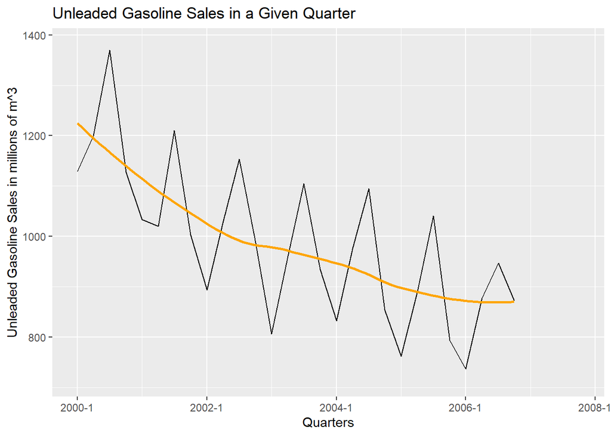

```r
# Plot the time series of UGS
autoplot(data_ts0$UGS/1000) +
  geom_smooth(fill = NA, color="orange", size = 1) +
  ggtitle("Unleaded Gasoline Sales in a Given Quarter") + xlab("Quarters") +
  ylab("Unleaded Gasoline Sales in millions of m^3")
```

Comments on the graph:

- As can be seen from the graph and smoothing line, there is a negative trend in the UGS variable. It means that the sales of the unleaded gasoline tend to decrease over time. This trend also can be interpreted as, the UGS data are not mean stationary since mean of UGS decreases over time.
- Additionally, there is an obvious seasonality in the UGS data. The sales of the unleaded gasoline are tend to be lower at first quarters, which corresponds to winters and to be higher at the third quarters, which corresponds to summers.
- Lastly, the time series of UGS seem covariance stationary since the deviation of the data does not change over time.

## Regression with Given Independent Variables

Let’s start to create regression models. I will start with given independent variables to check how much they explain about UGS variable. Before doing that, I will check the correlation pairs of the independent variables with UGS to find convenient variables to use in my regression analysis.

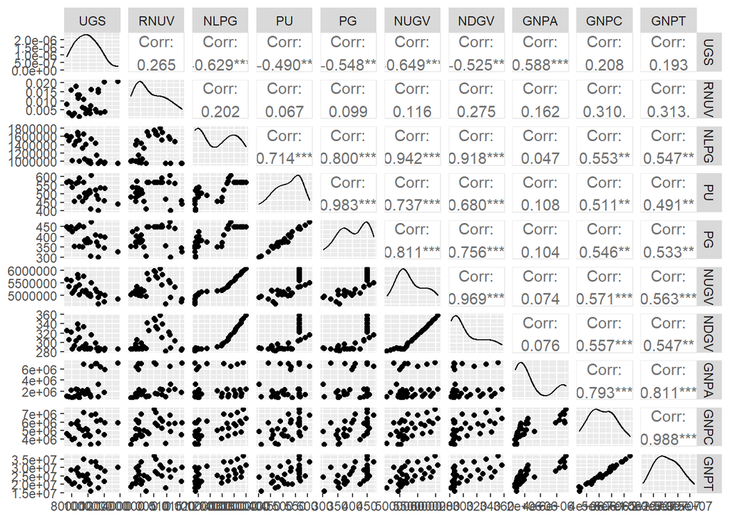

```r
# Correlation pairs of given variables
ggpairs(data[2:11])
```

By checking the correlations pairs, it can be said that NLPG, PU, PG, NUGV, NDGV and GNPA have significant correlations with UGS variable. However, from the UGS-GNPA scatter plot, it can be seen that the relation between them are not proper for linear regression. Hence, I will not use GNPA variable in the regression model.

First regression model contains NLGP, PU, PG, NUGV and NDGV variables.

```r
# Regression with given independent variables
model0 <- lm(UGS ~ NLPG + PU + PG + NUGV + NDGV, data = data_ts0)
summary(model0)
```

```
##
## Call:
## lm(formula = UGS ~ NLPG + PU + PG + NUGV + NDGV, data = data_ts0)
##
## Residuals:
##     Min      1Q  Median      3Q     Max
## -159862  -79649   -4431   54569  205988
##
## Coefficients:
##               Estimate Std. Error t value Pr(>|t|)
## (Intercept)  1.680e+06  8.774e+05   1.915   0.0686 .
## NLPG        -1.921e-01  2.346e-01  -0.819   0.4216
## PU           1.018e+03  2.775e+03   0.367   0.7172
## PG          -1.354e+03  3.595e+03  -0.377   0.7100
## NUGV        -5.666e-01  2.821e-01  -2.009   0.0570 .
## NDGV         8.383e+03  4.149e+03   2.021   0.0556 .
## ---
## Signif. codes:  0 '***' 0.001 '**' 0.01 '*' 0.05 '.' 0.1 ' ' 1
##
## Residual standard error: 115900 on 22 degrees of freedom
##   (4 observations deleted due to missingness)
## Multiple R-squared:  0.5202, Adjusted R-squared:  0.4112
## F-statistic: 4.771 on 5 and 22 DF,  p-value: 0.004199
```

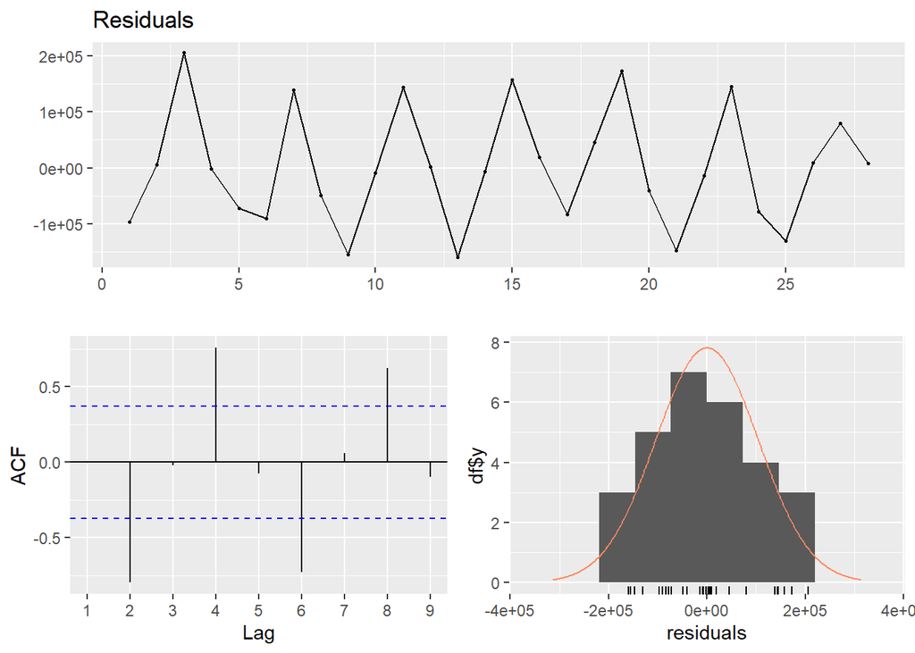

```
##
##  Breusch-Godfrey test for serial correlation of order up to 9
##
## data:  Residuals
## LM test = 22.984, df = 9, p-value = 0.006233
```

```r
checkresiduals(model0)
```

When we check the regression results, any of the independent variables seems significant. Therefore, this is not a valid and strong model. Instead of using each variable has a correlation with UGS variable, I decided to use the variable which has strongest correlation with UGS. Checking from the correlation pairs, NUGV has the strongest correlation.

```r
# Regression with only NUGV variable
model0_1 <- lm(UGS ~ NUGV, data_ts0)
summary(model0_1)
```

```
##
## Call:
## lm(formula = UGS ~ NUGV, data = data_ts0)
##
## Residuals:
##     Min      1Q  Median      3Q     Max
## -214947  -62190  -29110   89982  266389
##
## Coefficients:
##               Estimate Std. Error t value Pr(>|t|)
## (Intercept)  2.669e+06  3.877e+05   6.885 2.62e-07 ***
## NUGV        -3.234e-01  7.442e-02  -4.345 0.000189 ***
## ---
## Signif. codes:  0 '***' 0.001 '**' 0.01 '*' 0.05 '.' 0.1 ' ' 1
##
## Residual standard error: 117100 on 26 degrees of freedom
##   (4 observations deleted due to missingness)
## Multiple R-squared:  0.4207, Adjusted R-squared:  0.3984
## F-statistic: 18.88 on 1 and 26 DF,  p-value: 0.000189
```

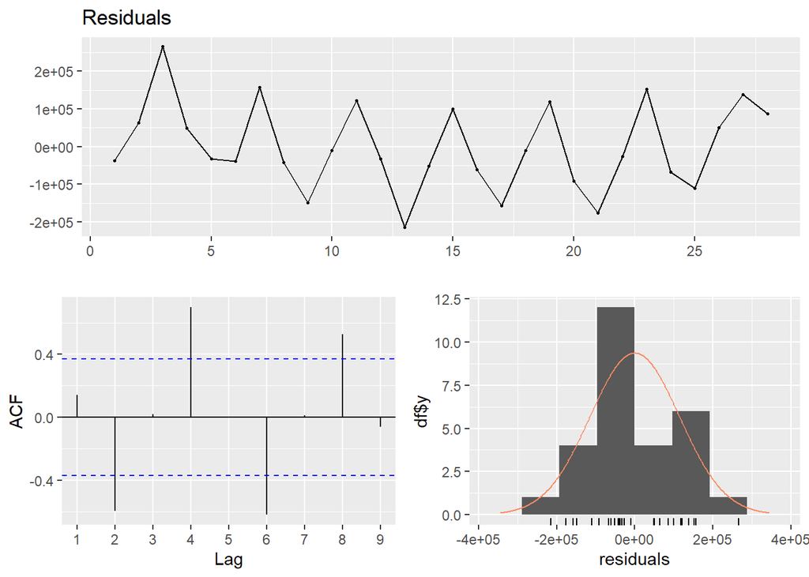

```
##
##  Breusch-Godfrey test for serial correlation of order up to 6
##
## data:  Residuals
## LM test = 18.978, df = 6, p-value = 0.004201
```

```r
checkresiduals(model0_1)
```

When we check the results of the model, it can be said that the NUGV variable is significant. The model is valid since F-statistic is high enough. The model does not explain much about the UGS variable since adjusted R-squared value is only 0.4, which means there are a lot of missing informations in the model. When we check the residuals, the seasonality patterns can be seen easily. The autocorrelation function also tells us about the seasonality since ACF values are high in lag 4 which corresponds to the same quarter in the next year. Breusch-Godfrey test also prove that residuals are serially dependent.

## Time Series Regression with Trend and Seasonality Variables

As a result of the previous regressions’ interpretations, it is better idea to construct a time series regression with trend and seasonality variables. Before doing that, let’s check the autocorrelation function of the UGS variable to be sure about the seasonality:

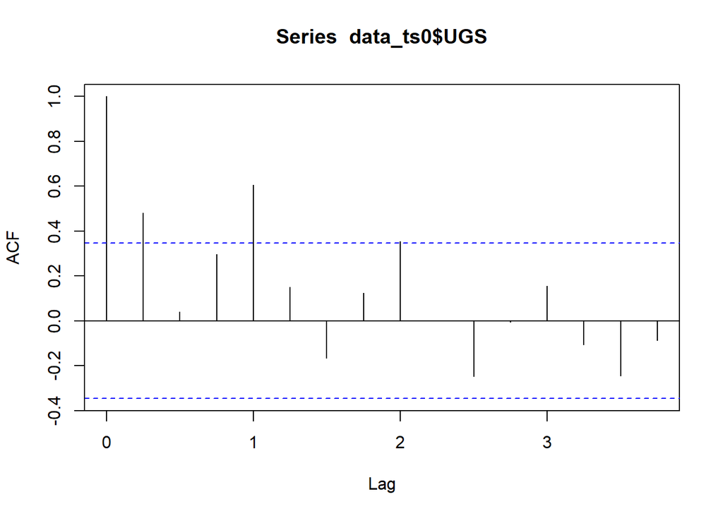

```r
# Autocorrelation function
acf(data_ts0$UGS, na.action = na.pass)
```

ACF of the UGS variable assures the seasonality in the UGS data and it is quarterly since ACF values peaks in the multiples of 4. We are also sure about trend thanks to plot of the UGS data. Before constructing the model, we need to add trend and seasonal variables into our data:

```r
# Add trend and seasonality
data$Trend <- 1:32 # since there are eight years of data and 4 quarters in a year
data$Quarter <- rep(1:4, 8)
data_ts1 <- xts(x = data[-1], order.by = data$Time, frequency = 4)
```

Now, we can construct the time series regression with trend and seasonality variables:

```r
# Time series linear regression with trend and seasonality
model1 <- lm(UGS ~ Trend + as.factor(Quarter), data = data_ts1)
summary(model1)
```

```
##
## Call:
## lm(formula = UGS ~ Trend + as.factor(Quarter), data = data_ts1)
##
## Residuals:
##    Min     1Q Median     3Q    Max
## -81167 -31283  -3458  28640  94502
##
## Coefficients:
##                     Estimate Std. Error t value Pr(>|t|)
## (Intercept)          1060372      23653  44.830  < 2e-16 ***
## Trend                 -13497       1147 -11.764 3.28e-11 ***
## as.factor(Quarter)2   121532      25987   4.677 0.000104 ***
## as.factor(Quarter)3   273619      26063  10.498 3.03e-10 ***
## as.factor(Quarter)4    95049      26189   3.629 0.001405 **
## ---
## Signif. codes:  0 '***' 0.001 '**' 0.01 '*' 0.05 '.' 0.1 ' ' 1
##
## Residual standard error: 48570 on 23 degrees of freedom
##   (4 observations deleted due to missingness)
## Multiple R-squared:  0.9119, Adjusted R-squared:  0.8966
## F-statistic: 59.53 on 4 and 23 DF,  p-value: 8.446e-12
```

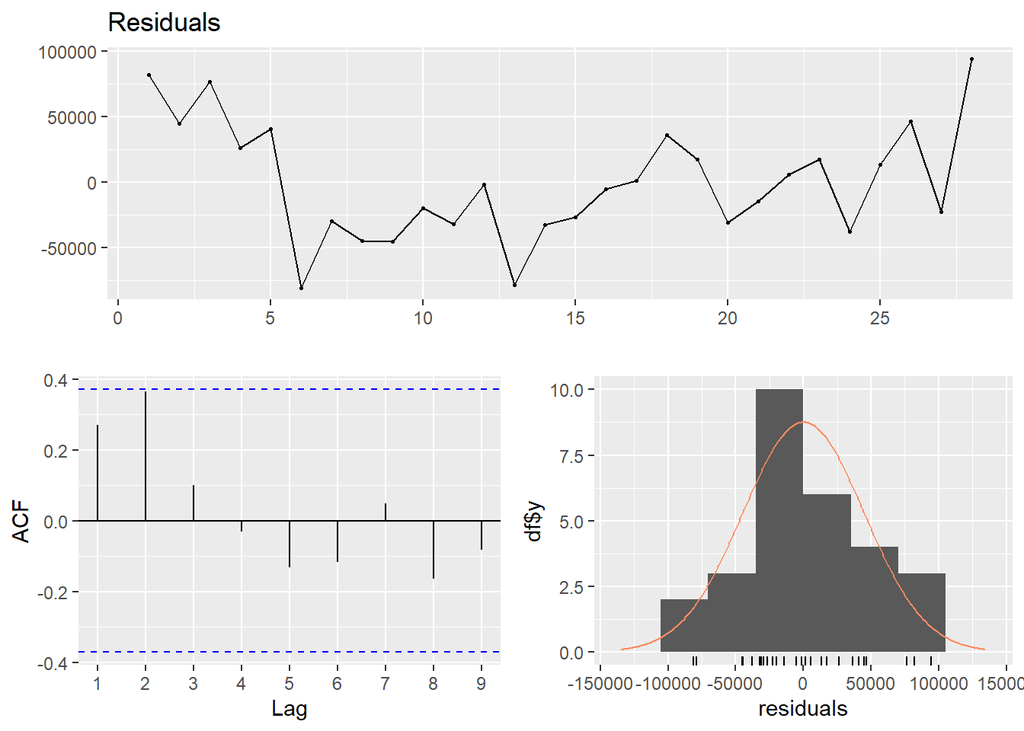

```
##
##  Breusch-Godfrey test for serial correlation of order up to 8
##
## data:  Residuals
## LM test = 11.462, df = 8, p-value = 0.1769
```

```r
checkresiduals(model1)
```

The results of the time series regression analysis with trend and seasonality terms seem pretty solid.

- Median of the of residuals are close to 0.
- Residuals seem normally distributed.
- All coefficients are significant.
- Adjusted R-squared value is almost 0.9
- F-statistics are very high.
- Finally, the result of the Breusch-Godfrey test says that residuals are serially independent.

## Time Series Regression with Trend, Seasonality and Lagged Variables

However, although the result of Breusch-Godfrey test says the opposite, I sense about some serial dependence in the plot of the residuals. To eliminate serial dependence and to improve the model, I will add lagged variables (previous quarters’ values) into the model. Lagged variables are UGS(t-4).

```r
# Add one year (4 quarter) lagged variable
data$UGS_lag4 <- c(rep(0,4), data$UGS[0:28])
data_ts2 <- xts(x = data[-1], order.by = data$Time, frequency = 4)
```

Now, we can build the time series regression model with trend, seasonality and lagged variables:

```r
# Time series linear regression with trend, seasonals and lagged variable
model2 <- lm(UGS ~ Trend + as.factor(Quarter) + UGS_lag4, data = data_ts2)
summary(model2)
```

```
##
## Call:
## lm(formula = UGS ~ Trend + as.factor(Quarter) + UGS_lag4, data = data_ts2)
##
## Residuals:
##    Min     1Q Median     3Q    Max
## -68879 -19501  -4069  15999  82994
##
## Coefficients:
##                       Estimate Std. Error t value Pr(>|t|)
## (Intercept)          1.108e+06  2.133e+04  51.921  < 2e-16 ***
## Trend               -1.199e+04  9.480e+02 -12.651 1.43e-11 ***
## as.factor(Quarter)2  1.276e+05  1.991e+04   6.407 1.91e-06 ***
## as.factor(Quarter)3  2.892e+05  2.026e+04  14.272 1.33e-12 ***
## as.factor(Quarter)4  9.355e+04  2.001e+04   4.674 0.000116 ***
## UGS_lag4            -8.569e-02  2.055e-02  -4.170 0.000398 ***
## ---
## Signif. codes:  0 '***' 0.001 '**' 0.01 '*' 0.05 '.' 0.1 ' ' 1
##
## Residual standard error: 37110 on 22 degrees of freedom
##   (4 observations deleted due to missingness)
## Multiple R-squared:  0.9508, Adjusted R-squared:  0.9396
## F-statistic: 85.04 on 5 and 22 DF,  p-value: 1.229e-13
```

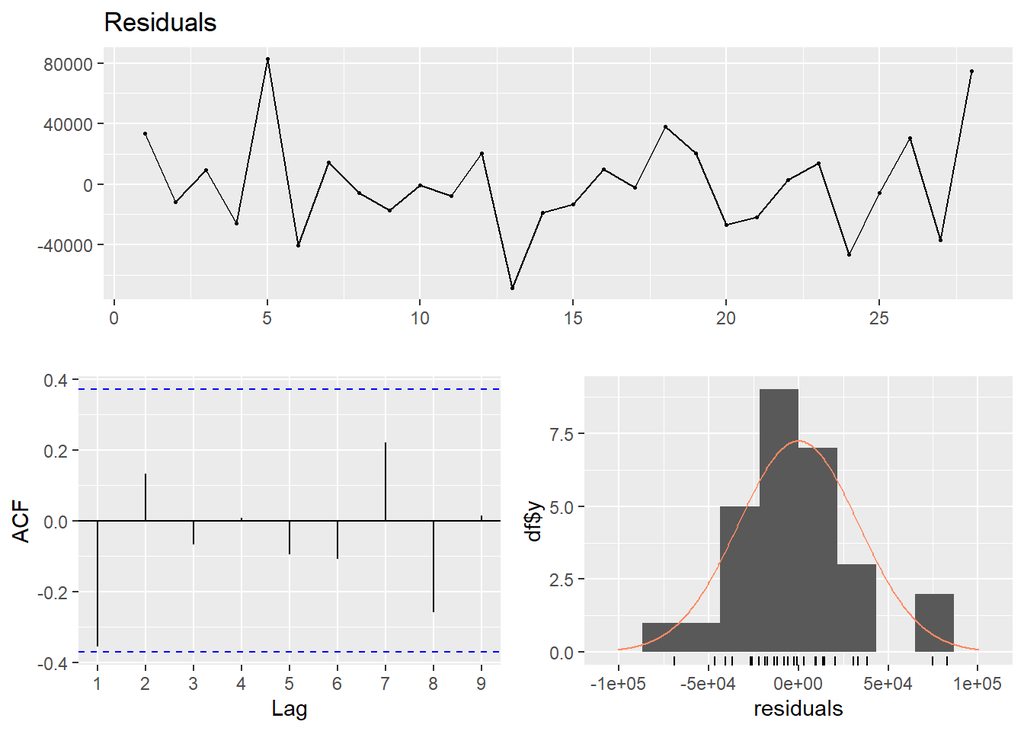

```
##
##  Breusch-Godfrey test for serial correlation of order up to 9
##
## data:  Residuals
## LM test = 10.25, df = 9, p-value = 0.3306
```

```r
checkresiduals(model2)
```

With the addition of the lagged variables, the model is obviously improved.

- Residual standard error decreased significantly.
- Adjusted R-squared increased to 0.94
- F-statistics increased to 85
- The result of the Breusch-Godfrey test for serial correlation increased to 0.33 which is a very strong result for serially independence.

## Time Series Regression with Trend, Seasonality, Lagged and Dummy Variables

When I checked the residuals again, there seems no serially dependence, but some residuals that is significantly greater than the others that weakens the model. The specific high errors are in the first quarter of 2001 and the last quarter of 2006. The reasons for these error need to be checked. It requires some deep research that I cannot do due to time restrictions. Instead, I will add some dummy variables to count for those huge errors and check whether the model is improved.

```r
# Add dummy variable to 5th and 28th observations
data$Dummy <- rep(0,32)
data$Dummy[c(5,28)] <- c(1,1)
data_ts3 <- xts(x = data[-1], order.by = data$Time, frequency = 4)
```

Now, we can build the time series regression model with trend, seasonality, lagged and dummy variables:

```r
# Time series linear regression with extra dummy variable
model2_1 <- lm(UGS ~ Trend + as.factor(Quarter) + UGS_lag4 + Dummy, data = data_ts3)
summary(model2_1)
```

```
##
## Call:
## lm(formula = UGS ~ Trend + as.factor(Quarter) + UGS_lag4 + Dummy,
##     data = data_ts3)
##
## Residuals:
##    Min     1Q Median     3Q    Max
## -54675 -13538    611  15525  39988
##
## Coefficients:
##                       Estimate Std. Error t value Pr(>|t|)
## (Intercept)          1.101e+06  1.572e+04  70.057  < 2e-16 ***
## Trend               -1.207e+04  6.956e+02 -17.356 6.26e-14 ***
## as.factor(Quarter)2  1.416e+05  1.494e+04   9.480 4.89e-09 ***
## as.factor(Quarter)3  3.043e+05  1.524e+04  19.962 3.89e-15 ***
## as.factor(Quarter)4  9.405e+04  1.468e+04   6.406 2.38e-06 ***
## UGS_lag4            -9.307e-02  1.516e-02  -6.139 4.32e-06 ***
## Dummy                9.353e+04  2.097e+04   4.460 0.000216 ***
## ---
## Signif. codes:  0 '***' 0.001 '**' 0.01 '*' 0.05 '.' 0.1 ' ' 1
##
## Residual standard error: 27220 on 21 degrees of freedom
##   (4 observations deleted due to missingness)
## Multiple R-squared:  0.9747, Adjusted R-squared:  0.9675
## F-statistic:   135 on 6 and 21 DF,  p-value: 1.155e-15
```

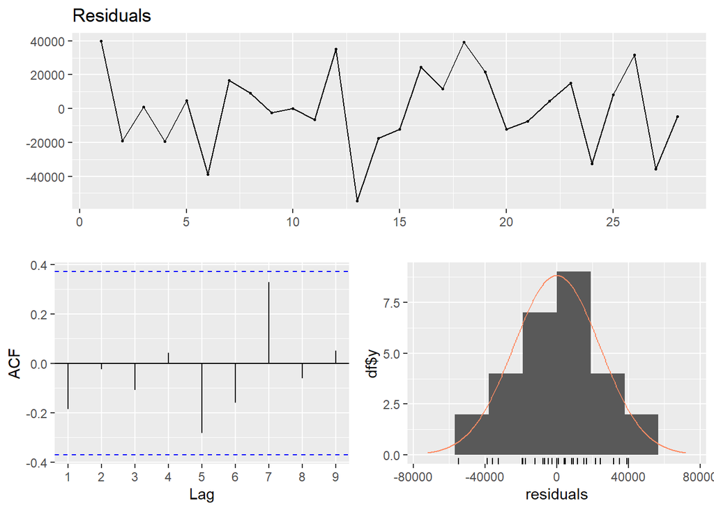

```
##
##  Breusch-Godfrey test for serial correlation of order up to 10
##
## data:  Residuals
## LM test = 13.701, df = 10, p-value = 0.1871
```

```r
checkresiduals(model2_1)
```

With the improvement of the dummy variable, the model is significantly improved again.

- The residual standard error decreased significantly.
- Median of the resiudal are closer to 0.
- Adjusted R-squared value increased to nearly 0.97
- F-statistics increased to 135 which shows the soundness of the model
- The only negative effect of the addition of the dummy variable is the result of the Breusch-Godfrey test for serial correlation decreased to 0.18 from 0.33, which is also very strong evidence for serially independence. Therefore we can compensate the decrease of the result.

## Addition of NUGV Independent Variable to Model

Even we have very sound and valid time series linear regression model, I want to check if the addition of the NUGV variable, which is significantly correlated to UGS variable, will improve our model

```r
model3 <- lm(UGS ~ Trend + as.factor(Quarter) + UGS_lag4 + NUGV + Dummy, data = data_ts3)
summary(model3)
```

```
##
## Call:
## lm(formula = UGS ~ Trend + as.factor(Quarter) + UGS_lag4 + NUGV +
##     Dummy, data = data_ts3)
##
## Residuals:
##    Min     1Q Median     3Q    Max
## -56060 -20399   3117  15566  43176
##
## Coefficients:
##                       Estimate Std. Error t value Pr(>|t|)
## (Intercept)          1.651e+06  3.609e+05   4.575 0.000184 ***
## Trend               -7.898e+03  2.818e+03  -2.803 0.010996 *
## as.factor(Quarter)2  1.452e+05  1.468e+04   9.894 3.79e-09 ***
## as.factor(Quarter)3  3.095e+05  1.518e+04  20.394 7.44e-15 ***
## as.factor(Quarter)4  9.932e+04  1.465e+04   6.779 1.36e-06 ***
## UGS_lag4            -9.533e-02  1.478e-02  -6.450 2.73e-06 ***
## NUGV                -1.179e-01  7.729e-02  -1.526 0.142792
## Dummy                1.097e+05  2.294e+04   4.783 0.000113 ***
## ---
## Signif. codes:  0 '***' 0.001 '**' 0.01 '*' 0.05 '.' 0.1 ' ' 1
##
## Residual standard error: 26400 on 20 degrees of freedom
##   (4 observations deleted due to missingness)
## Multiple R-squared:  0.9774, Adjusted R-squared:  0.9694
## F-statistic: 123.4 on 7 and 20 DF,  p-value: 4.745e-15
```

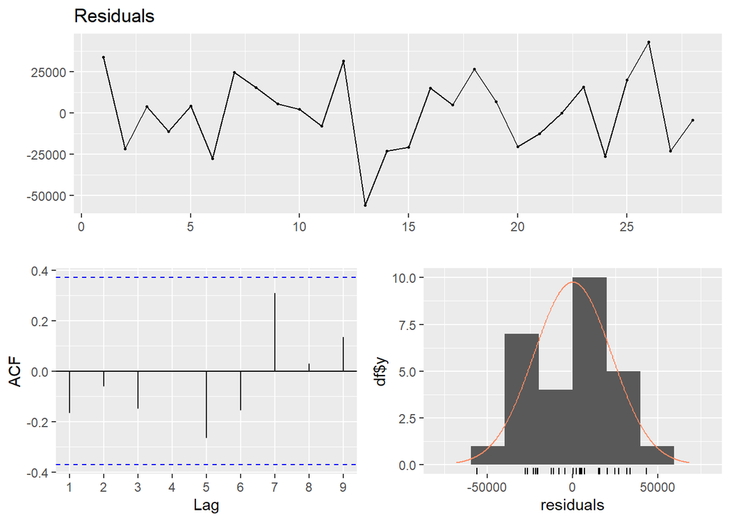

```
##
##  Breusch-Godfrey test for serial correlation of order up to 11
##
## data:  Residuals
## LM test = 17.256, df = 11, p-value = 0.1005
```

```r
checkresiduals(model3)
```

After checking the results, we can say that addition of the NUGV variable distorted our model in a some way.

- First of all, NUGV variable is not significant in the model.
- F-statistics value decreased.
- Breusch-Godfrey test for serial correlation result decreased.

Therefore, I will not add the NUGV variable to my model.

## Forecast for the Quarters of 2007

Finally, I can forecast the values of sales of unleaded gasoline for the each quarter of 2007. To forecast, I will use the model with trend, seasonality, lagged and dummy variables. My forecasts are as follows:

```r
# Predict the missing values with model2 which gives the best model
predicted_UGS <- predict(model2_1,data_ts3)

# Final time series that contains predicted and actual UGS values
data_ts_final <- xts(x = data.frame(data$UGS, predicted_UGS), order.by = data$Time, frequency = 4)

# Predicted values for the four quarters of 2007
predicted_UGS[29:32]
```

```
##  2007 Q1  2007 Q2  2007 Q3  2007 Q4
## 682399.9 798850.4 942980.8 727630.0
```

You can also see predicted vs. actual UGS values in the following graph:

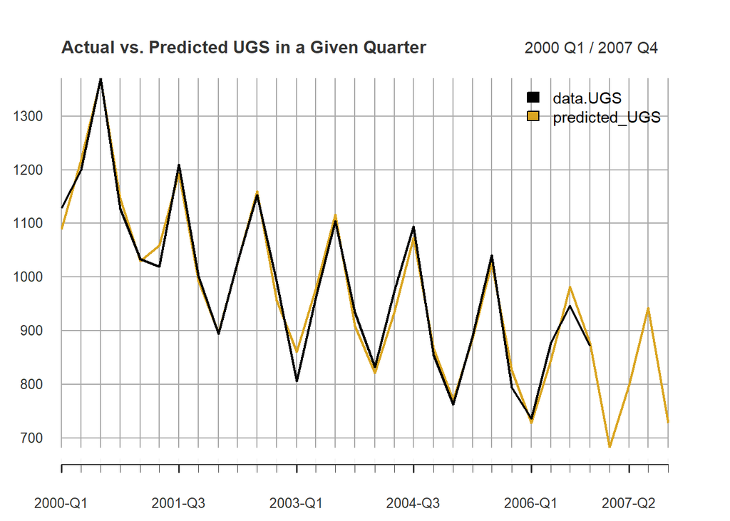

```r
# Plot predicted vs actual UGS
plot(data_ts_final/1000,
     legend.loc = "topright",
     main = "Actual vs. Predicted UGS in a Given Quarter",
     minor.ticks = "quarters",
     grid.ticks.on = "quarters",
     yaxis.right = FALSE, col = c("black","goldenrod"))
```

It can be said that my time series regression model fits the actual data very well.

# Conclusion

In conclusion, for the forecast of the UGS variable, the given independent variables are redundant. Only NUGV variable explains some information on UGS. On the other hand, trend and seasonality terms explain a lot about UGS variable. In addition to them, lagged and dummy variables are included to improve the model. All together, they are constructed pretty convenient model to forecast the four quarters of 2007.